# Business Analytics - Evidence 1

Leung Wan Hoi - A01761528

2023-05-05

# 1 Front Matter

## 1.1 Title Page

**Problem Setup**

We start with three questions:

[figure not shown]

1. What makes successful movies?
2. What makes a movie successful or unsuccessful?
3. What would you recommend to the major production companies?

## 1.2 Table of Contents

1. Front Matter

   1.1. Title Page  
   1.2. Table of Contents  
   1.3. Abstract
2. Body

   3.1. Appendices  
   3.2. Reference List

## 1.3 Abstract

The study identified several challenges in the data cleaning process, such as dealing with missing values and conflicting data. The findings suggest that careful data cleaning and preprocessing are essential for producing accurate and reliable insights about the factors that contribute to the success of movies. Further research could explore the relationship between critical ratings and box office revenue, or investigate the impact of social media on the success of movies.

# 2 Body

## 2.1 Introduction

These files contain metadata for all 45,000 movies listed in the Full MovieLens Dataset. The dataset consists of movies released on or before July 2017. Data points include cast, crew, plot keywords, budget, revenue, posters, release dates, languages, production companies, countries, TMDB vote counts and vote averages.

This dataset also has files containing 26 million ratings from 270,000 users for all 45,000 movies. Ratings are on a scale of 1-5 and have been obtained from the official GroupLens website.

## 2.2 Objectives

This study aimed to analyze the factors that contribute to the success of movies using data cleaning techniques in R. The dataset included information on movie characteristics such as genre, cast, budget, release date, and box office revenue. The data cleaning process involved identifying and addressing missing values, outliers, and inconsistencies in the dataset.

## 2.4 Data Cleaning

```r
# we see an overview of the database to detect errors
glimpse(movies_dataset)
```

```
## Rows: 45,466
## Columns: 24
## $ adult                 <chr> "False", "False", "False", "False", "False", "Fa…
## $ belongs_to_collection <chr> "{'id': 10194, 'name': 'Toy Story Collection', '…
## $ budget                <chr> "30000000", "65000000", "0", "16000000", "0", "6…
## $ genres                <chr> "[{'id': 16, 'name': 'Animation'}, {'id': 35, 'n…
## $ homepage              <chr> "http://toystory.disney.com/toy-story", "", "", …
## $ id                    <chr> "862", "8844", "15602", "31357", "11862", "949",…
## $ imdb_id               <chr> "tt0114709", "tt0113497", "tt0113228", "tt011488…
## $ original_language     <chr> "en", "en", "en", "en", "en", "en", "en", "en", …
## $ original_title        <chr> "Toy Story", "Jumanji", "Grumpier Old Men", "Wai…
## $ overview              <chr> "Led by Woody, Andy's toys live happily in his r…
## $ popularity            <chr> "21.946943", "17.015539", "11.7129", "3.859495",…
## $ poster_path           <chr> "/rhIRbceoE9lR4veEXuwCC2wARtG.jpg", "/vzmL6fP7aP…
## $ production_companies  <chr> "[{'name': 'Pixar Animation Studios', 'id': 3}]"…
## $ production_countries  <chr> "[{'iso_3166_1': 'US', 'name': 'United States of…
## $ release_date          <chr> "1995-10-30", "1995-12-15", "1995-12-22", "1995-…
## $ revenue               <dbl> 373554033, 262797249, 0, 81452156, 76578911, 187…
## $ runtime               <dbl> 81, 104, 101, 127, 106, 170, 127, 97, 106, 130, …
## $ spoken_languages      <chr> "[{'iso_639_1': 'en', 'name': 'English'}]", "[{'…
## $ status                <chr> "Released", "Released", "Released", "Released", …
## $ tagline               <chr> "", "Roll the dice and unleash the excitement!",…
## $ title                 <chr> "Toy Story", "Jumanji", "Grumpier Old Men", "Wai…
## $ video                 <chr> "False", "False", "False", "False", "False", "Fa…
## $ vote_average          <dbl> 7.7, 6.9, 6.5, 6.1, 5.7, 7.7, 6.2, 5.4, 5.5, 6.6…
## $ vote_count            <int> 5415, 2413, 92, 34, 173, 1886, 141, 45, 174, 119…
```

```r
summary(movies_dataset)
```

```
##     adult           belongs_to_collection    budget             genres
##  Length:45466       Length:45466          Length:45466       Length:45466
##  Class :character   Class :character      Class :character   Class :character
##  Mode  :character   Mode  :character      Mode  :character   Mode  :character
##
##
##
##
##    homepage              id              imdb_id          original_language
##  Length:45466       Length:45466       Length:45466       Length:45466
##  Class :character   Class :character   Class :character   Class :character
##  Mode  :character   Mode  :character   Mode  :character   Mode  :character
##
##
##
##
##  original_title       overview          popularity        poster_path
##  Length:45466       Length:45466       Length:45466       Length:45466
##  Class :character   Class :character   Class :character   Class :character
##  Mode  :character   Mode  :character   Mode  :character   Mode  :character
##
##
##
##
##  production_companies production_countries release_date
##  Length:45466         Length:45466         Length:45466
##  Class :character     Class :character     Class :character
##  Mode  :character     Mode  :character     Mode  :character
##
##
##
##
##     revenue             runtime        spoken_languages      status
##  Min.   :0.000e+00   Min.   :   0.00   Length:45466       Length:45466
##  1st Qu.:0.000e+00   1st Qu.:  85.00   Class :character   Class :character
##  Median :0.000e+00   Median :  95.00   Mode  :character   Mode  :character
##  Mean   :1.121e+07   Mean   :  94.13
##  3rd Qu.:0.000e+00   3rd Qu.: 107.00
##  Max.   :2.788e+09   Max.   :1256.00
##  NA's   :6           NA's   :263
##    tagline             title              video            vote_average
##  Length:45466       Length:45466       Length:45466       Min.   : 0.000
##  Class :character   Class :character   Class :character   1st Qu.: 5.000
##  Mode  :character   Mode  :character   Mode  :character   Median : 6.000
##                                                           Mean   : 5.618
##                                                           3rd Qu.: 6.800
##                                                           Max.   :10.000
##                                                           NA's   :6
##    vote_count
##  Min.   :    0.0
##  1st Qu.:    3.0
##  Median :   10.0
##  Mean   :  109.9
##  3rd Qu.:   34.0
##  Max.   :14075.0
##  NA's   :6
```

### 2.4.1 Deleating variables

In this step we are deleting variables that are not necessary for our analysis. And observations that don’t contain nothing.

```r
# we eliminate variables we don't need
movies_dataset <- subset(movies_dataset, select = -c(belongs_to_collection, homepage, overview, poster_path, tagline))
```

### 2.4.2 Data types problems

We will now continue correcting the data types of each variable.

```r
# assign the correct data type to each variable
movies_dataset <- movies_dataset %>%
  mutate(adult = as.logical(adult),
         budget = as.numeric(budget),
         original_language = as.factor(original_language),
         popularity = as.numeric(popularity),
         release_date = as.Date(release_date),
         status = as.factor(status),
         video = as.logical(video),
         vote_count = as.integer(vote_count))
# specify empty entry as
levels(movies_dataset$status)[1] <- "Not specified"

# view changes
summary(movies_dataset)
```

```
##    adult             budget             genres               id
##  Mode :logical   Min.   :        0   Length:45466       Length:45466
##  FALSE:45454     1st Qu.:        0   Class :character   Class :character
##  TRUE :9         Median :        0   Mode  :character   Mode  :character
##  NA's :3         Mean   :  4224579
##                  3rd Qu.:        0
##                  Max.   :380000000
##                  NA's   :3
##    imdb_id          original_language original_title       popularity
##  Length:45466       en     :32269     Length:45466       Min.   :  0.0000
##  Class :character   fr     : 2438     Class :character   1st Qu.:  0.3859
##  Mode  :character   it     : 1529     Mode  :character   Median :  1.1277
##                     ja     : 1350                        Mean   :  2.9215
##                     de     : 1080                        3rd Qu.:  3.6789
##                     es     :  994                        Max.   :547.4883
##                     (Other): 5806                        NA's   :6
##  production_companies production_countries  release_date
##  Length:45466         Length:45466         Min.   :1874-12-09
##  Class :character     Class :character     1st Qu.:1978-10-06
##  Mode  :character     Mode  :character     Median :2001-08-30
##                                            Mean   :1992-05-15
##                                            3rd Qu.:2010-12-17
##                                            Max.   :2020-12-16
##                                            NA's   :90
##     revenue             runtime        spoken_languages
##  Min.   :0.000e+00   Min.   :   0.00   Length:45466
##  1st Qu.:0.000e+00   1st Qu.:  85.00   Class :character
##  Median :0.000e+00   Median :  95.00   Mode  :character
##  Mean   :1.121e+07   Mean   :  94.13
##  3rd Qu.:0.000e+00   3rd Qu.: 107.00
##  Max.   :2.788e+09   Max.   :1256.00
##  NA's   :6           NA's   :263
##              status         title             video          vote_average
##  Not specified  :   87   Length:45466       Mode :logical   Min.   : 0.000
##  Canceled       :    2   Class :character   FALSE:45367     1st Qu.: 5.000
##  In Production  :   20   Mode  :character   TRUE :93        Median : 6.000
##  Planned        :   15                      NA's :6         Mean   : 5.618
##  Post Production:   98                                      3rd Qu.: 6.800
##  Released       :45014                                      Max.   :10.000
##  Rumored        :  230                                      NA's   :6
##    vote_count
##  Min.   :    0.0
##  1st Qu.:    3.0
##  Median :   10.0
##  Mean   :  109.9
##  3rd Qu.:   34.0
##  Max.   :14075.0
##  NA's   :6
```

### 2.4.3 Dealing with missing values

As a team, we took the decision to eliminate the observations that had nothing or that were marked as N/A, this because in some columns if they were replaced by the mean or another value it would affect the final result, besides that in some columns that were characters were blank and there was no data to replace them with.

```r
# Check for missing values
colSums(is.na(movies_dataset))
```

```
##                adult               budget               genres
##                    3                    3                    0
##                   id              imdb_id    original_language
##                    0                    0                    0
##       original_title           popularity production_companies
##                    0                    6                    0
## production_countries         release_date              revenue
##                    0                   90                    6
##              runtime     spoken_languages               status
##                  263                    0                    0
##                title                video         vote_average
##                    0                    6                    6
##           vote_count
##                    6
```

```r
# Filter out rows with missing or zero values in relevant columns
movies_dataset <- subset(movies_dataset, !is.na(revenue), video != 0 & !is.na(video))
movies_dataset <- subset(movies_dataset,!is.na(vote_average),!is.na(vote_count))
movies_dataset <- subset(movies_dataset,!is.na(release_date))
movies_dataset <- subset(movies_dataset,!is.na(runtime))
movies_dataset <- subset(movies_dataset, !is.na(budget), !is.na(popularity))

# Check for any remaining missing values
colSums(is.na(movies_dataset))
```

```
##                adult               budget               genres
##                    0                    0                    0
##                   id              imdb_id    original_language
##                    0                    0                    0
##       original_title           popularity production_companies
##                    0                    0                    0
## production_countries         release_date              revenue
##                    0                    0                    0
##              runtime     spoken_languages               status
##                    0                    0                    0
##                title                video         vote_average
##                    0                    0                    0
##           vote_count
##                    0
```

### 2.4.4 Out-of-range values

Now we have to identify the out-of-range values in the number columns, such as budget, popularity, revenue, run time, vote_average, vote_count.

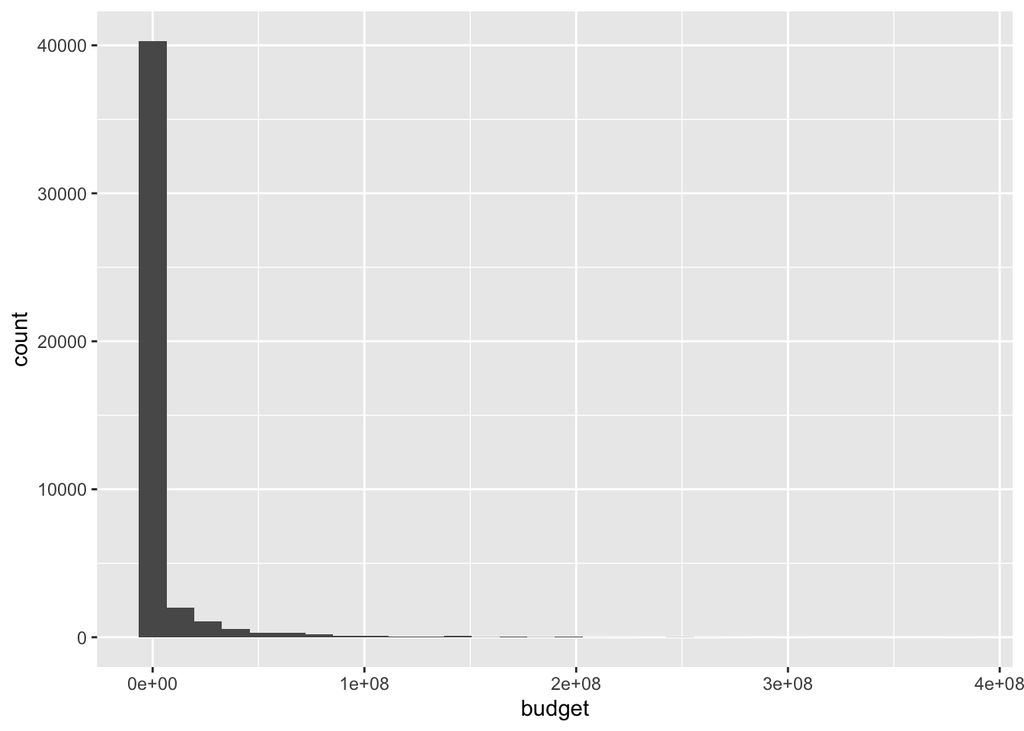

```r
# first, by using histograms for each variable, we check for out-of-range values
ggplot(movies_dataset, aes(budget)) + geom_histogram()
```

```r
summary(movies_dataset$budget)
```

```
##      Min.   1st Qu.    Median      Mean   3rd Qu.      Max.
##         0         0         0   4255220         0 380000000
```

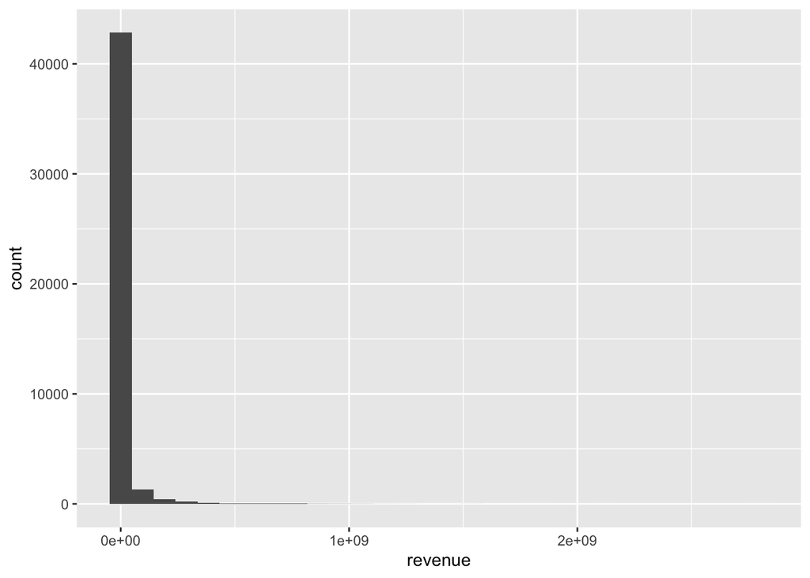

```r
ggplot(movies_dataset, aes(revenue)) + geom_histogram()
```

```r
summary(movies_dataset$revenue)
```

```
##      Min.   1st Qu.    Median      Mean   3rd Qu.      Max.
## 0.000e+00 0.000e+00 0.000e+00 1.129e+07 0.000e+00 2.788e+09
```

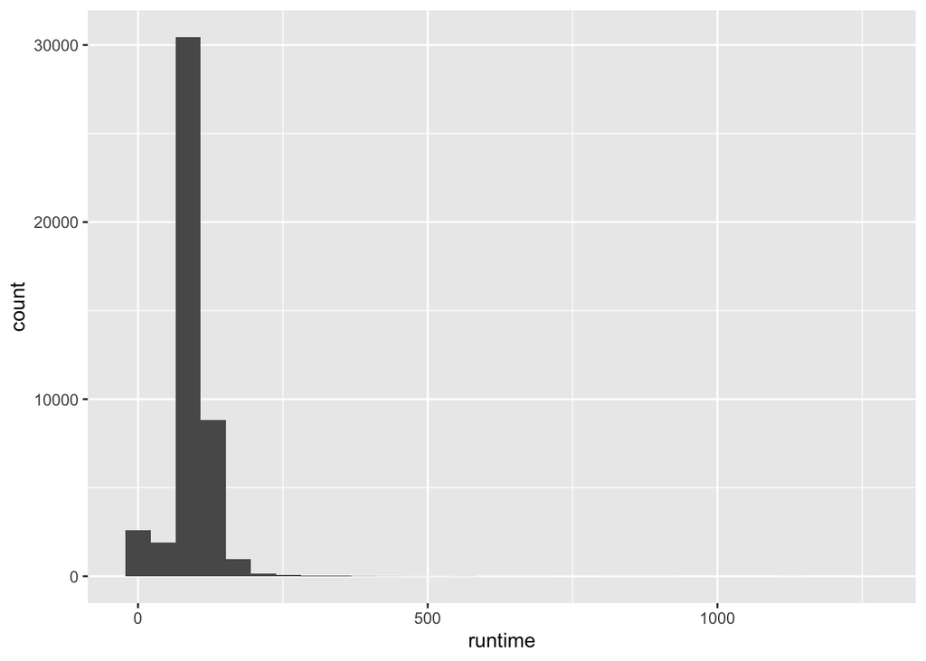

```r
ggplot(movies_dataset, aes(runtime)) + geom_histogram()
```

```r
summary(movies_dataset$runtime)
```

```
##    Min. 1st Qu.  Median    Mean 3rd Qu.    Max.
##    0.00   85.00   95.00   94.18  107.00 1256.00
```

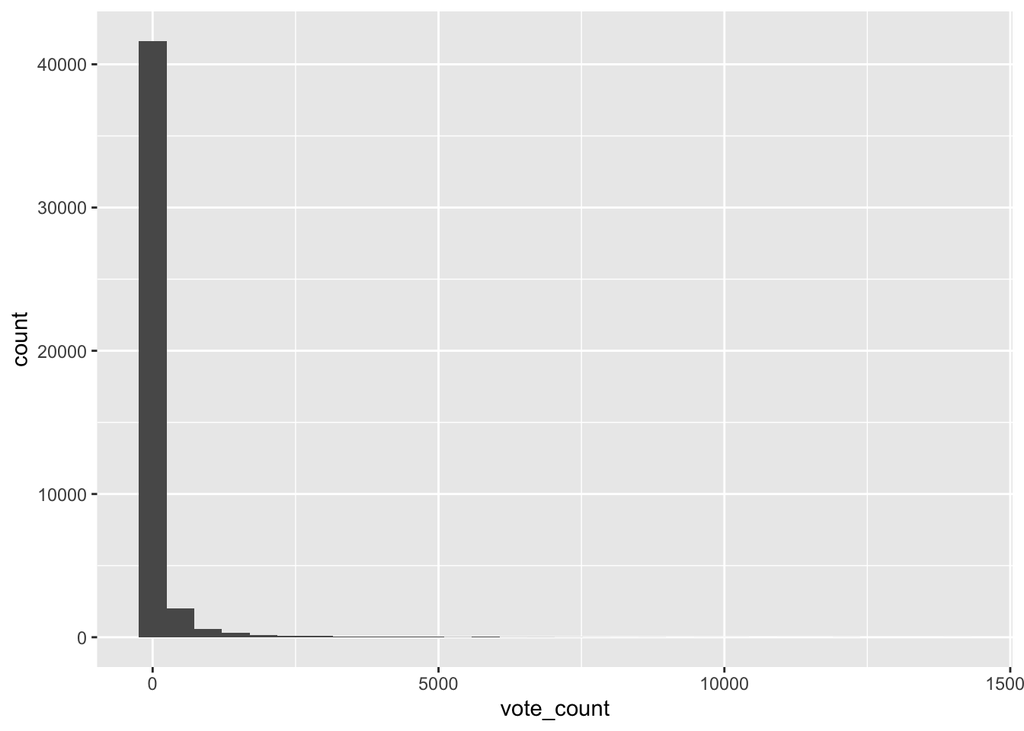

```r
ggplot(movies_dataset, aes(vote_count)) + geom_histogram()
```

```r
summary(movies_dataset$vote_count)
```

```
##    Min. 1st Qu.  Median    Mean 3rd Qu.    Max.
##     0.0     3.0    10.0   110.7    35.0 14075.0
```

On the other hand we have that in the case of the variable of **revenue**, most of the movies have had a revenue less than 1,000,000,000 and because there is a couple of movies that have more that that, we have that shape in the histogram. Also we have to visualize that there are allot of values with 0 in the revenue.

#### 2.4.4.1 Runtime

Let’s start fixing the out of range values of **run time**.

```r
# we set the time limit
movies_dataset <- movies_dataset %>%
  mutate(runtime = ifelse(runtime<240, runtime, 240)) %>%
  mutate(runtime = ifelse(runtime==0, 1, runtime))
summary(movies_dataset$runtime)
```

```
##    Min. 1st Qu.  Median    Mean 3rd Qu.    Max.
##     1.0    85.0    95.0    93.6   107.0   240.0
```

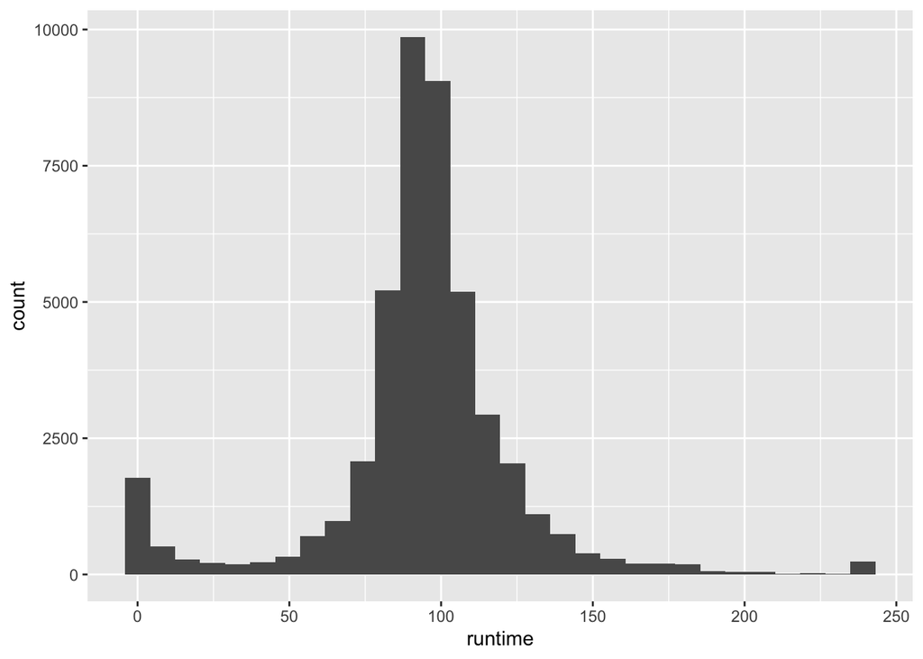

```r
# view the changes
ggplot(movies_dataset, aes(runtime)) + geom_histogram()
```

```r
summary(movies_dataset$runtime)
```

```
##    Min. 1st Qu.  Median    Mean 3rd Qu.    Max.
##     1.0    85.0    95.0    93.6   107.0   240.0
```

#### 2.4.4.2 Revenue

The next variable with out of range variable is **revenue**

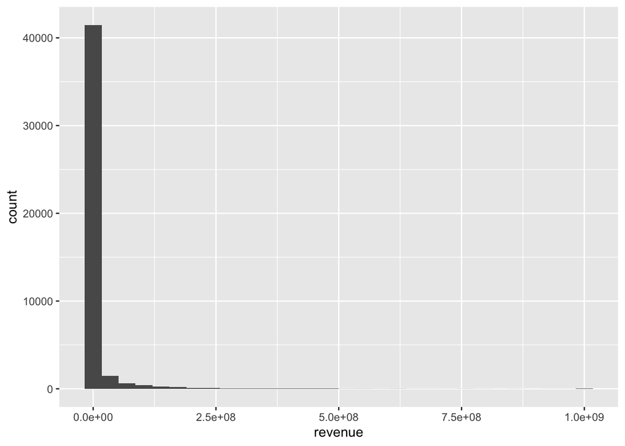

```r
# we set the revenue limit
movies_dataset <- movies_dataset %>%
  mutate(revenue = ifelse(revenue<1000000000, revenue, 1000000000)) %>%
  mutate(revenue = ifelse(revenue==0, 1, revenue))

# we view the changes
ggplot(movies_dataset, aes(revenue)) + geom_histogram()
```

```r
summary(movies_dataset$revenue)
```

```
##      Min.   1st Qu.    Median      Mean   3rd Qu.      Max.
## 1.000e+00 1.000e+00 1.000e+00 1.111e+07 1.000e+00 1.000e+09
```

#### 2.4.4.3 Vote count

And finally we have the variable **vote count**

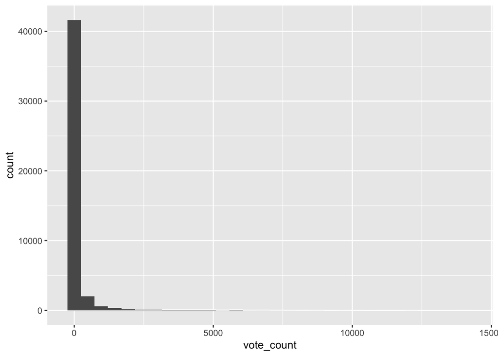

```r
movies_dataset <- movies_dataset %>%
  mutate(vote_count = ifelse(vote_count>1, vote_count, 1))

ggplot(movies_dataset, aes(vote_count)) + geom_histogram()
```

```r
summary(movies_dataset$vote_count)
```

```
##    Min. 1st Qu.  Median    Mean 3rd Qu.    Max.
##     1.0     3.0    10.0   110.7    35.0 14075.0
```

#### 2.4.4.4 Budget

The next variable with out of range observations is **budget**

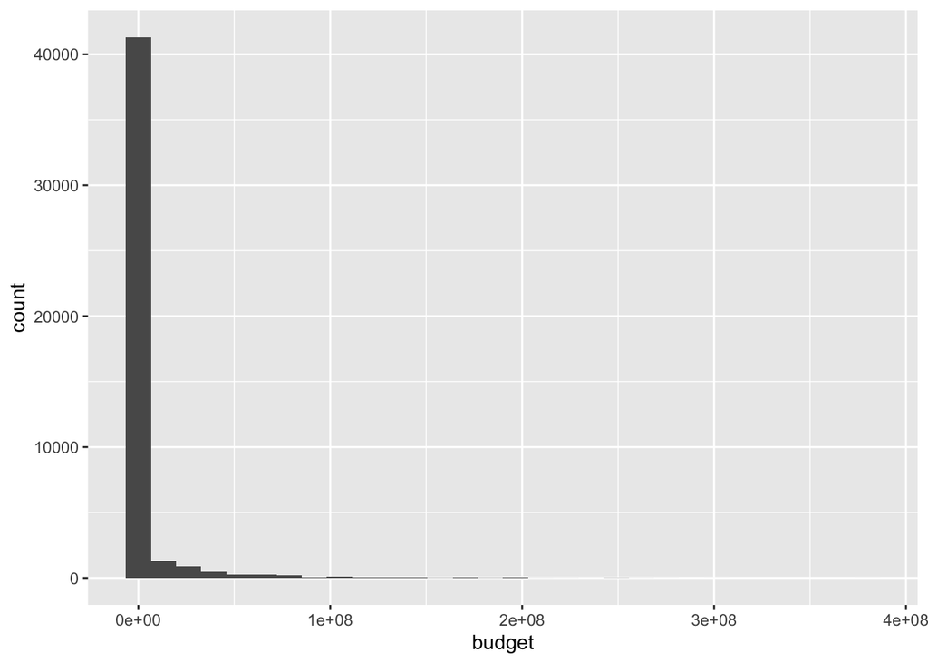

```r
# we set the revenue limit
movies_dataset <- movies_dataset %>%
  mutate(budget = ifelse(revenue<100, 100, budget)) %>%
  mutate(budget = ifelse(revenue==0, 100, budget))

# we view the changes
ggplot(movies_dataset, aes(budget)) + geom_histogram()
```

```r
summary(movies_dataset$budget)
```

```
##      Min.   1st Qu.    Median      Mean   3rd Qu.      Max.
##         0       100       100   3705565       100 380000000
```

### 2.4.5 Cleaning character variables

So we decided that the variables with several options within the same variable should be divided in 3 different variables and put each option in a different column.

Let’s start with the cleaning process of these variables

#### 2.4.5.1 Spoken languages

This variable includes the different languages that spoken in the film.

```r
# change datatype to character
movies_dataset$languages_string <- as.character(movies_dataset$spoken_languages)
```

```r
# separate the character string with ":"
new_language <- str_split_fixed(movies_dataset$languages_string, ":", n = Inf)
```

```r
# extract data with spoken_languages data
new_language <- new_language[,c(3,5,7)]
```

```r
# separate the character string with ","
new_language1 <- str_split_fixed(new_language[,1], ",", n = Inf)
new_language2 <- str_split_fixed(new_language[,2], ",", n = Inf)
new_language3 <- str_split_fixed(new_language[,3], ",", n = Inf)
new_language <- cbind(new_language1,new_language2,new_language3)
new_language <- new_language[,c(1,3,5)]
```

```r
# change datatype to dataframe
new_language <- as.data.frame(new_language)
```

```r
# replace all punctuation characters with space by adding new column
new_language <- new_language %>%
  mutate(language1 = str_replace_all(new_language$V1, "[[:punct:]]", " "))
new_language <- new_language %>%
  mutate(language2 = str_replace_all(new_language$V2, "[[:punct:]]", " "))
new_language <- new_language %>%
  mutate(language3 = str_replace_all(new_language$V3, "[[:punct:]]", " "))
```

```r
# extract the cleaned columns
language_clean <- new_language[,4:6]
```

```r
# remove rightmost space
language_clean$language1 <- str_trim(language_clean$language1, "right")
language_clean$language2 <- str_trim(language_clean$language2, "right")
language_clean$language3 <- str_trim(language_clean$language3, "right")
```

```r
# change datatype to factor
language_clean$language1 <- as.factor(language_clean$language1)
language_clean$language2 <- as.factor(language_clean$language2)
language_clean$language3 <- as.factor(language_clean$language3)
```

```r
# specify all empty entry as "Not specified"
levels(language_clean$language1)[1] <- "Not specified"
levels(language_clean$language2)[1] <- "Not specified"
levels(language_clean$language3)[1] <- "Not specified"
```

```r
# combine the cleaned genre data to the original movies data set
movies_dataset <- cbind(movies_dataset, language_clean)
```

```r
summary(language_clean)
```

```
##          language1             language2             language3
##    English    :26815   Not specified:37383   Not specified:42685
##  Not specified: 3891     English    : 1593     Deutsch    :  327
##    Français   : 2410     Français   : 1473     Español    :  308
##    日本語     : 1388     Deutsch    :  917     Français   :  234
##    Italiano   : 1383     Español    :  781     English    :  232
##    Deutsch    : 1269     Italiano   :  615     Italiano   :  225
##  (Other)      : 7974   (Other)      : 2368   (Other)      : 1119
```

```r
movies_dataset %>%
  dplyr::count(language1, sort= TRUE)
```

```
##             language1     n
## 1             English 26815
## 2       Not specified  3891
## 3            Français  2410
## 4              日本語  1388
## 5            Italiano  1383
## 6             Deutsch  1269
## 7             Español  1125
## 8             Pусский   897
## 9               हिन्दी   547
## 10      한국어 조선말   446
## 11             普通话   413
## 12    广州话   廣州話   405
## 13            svenska   336
## 14          Português   324
```

[output cut: 57 more lines]

```r
movies_dataset %>%
  dplyr::count(language2, sort= TRUE)
```

```
##             language2     n
## 1       Not specified 37383
## 2             English  1593
## 3            Français  1473
## 4             Deutsch   917
## 5             Español   781
## 6            Italiano   615
## 7             Pусский   326
## 8              日本語   239
## 9              普通话   222
## 10             Polski   159
## 11          Português   159
## 12             Magyar   137
## 13              हिन्दी   126
## 14            svenska   122
```

[output cut: 54 more lines]

```r
movies_dataset %>%
  dplyr::count(language3, sort= TRUE)
```

```
##             language3     n
## 1       Not specified 42685
## 2             Deutsch   327
## 3             Español   308
## 4            Français   234
## 5             English   232
## 6            Italiano   225
## 7             Pусский   211
## 8              普通话    88
## 9              日本語    87
## 10             Polski    82
## 11          Português    65
## 12             Magyar    59
## 13            svenska    57
## 14              Latin    41
```

[output cut: 47 more lines]

```r
movies_dataset <- subset (movies_dataset, select = -spoken_languages)
```

#### 2.4.5.2 Genres

This variable includes the different genres with which the film is associated. We repeat the similar steps that used for the above spoken_languages variable.

```r
movies_dataset$genres_string <- as.character(movies_dataset$genres)
```

```r
new_genres <- str_split_fixed(movies_dataset$genres_string, ":", n = Inf)
```

```r
new_genres <- new_genres[,1:7]
```

```r
new_genres <- new_genres[, c(3,5,7)]
```

```r
summary(new_genres)
```

```
##       V1                 V2                 V3
##  Length:45130       Length:45130       Length:45130
##  Class :character   Class :character   Class :character
##  Mode  :character   Mode  :character   Mode  :character
```

```r
new_genres <- as.data.frame(new_genres)
```

```r
new_genres <- new_genres %>%
  mutate(genre1 = str_replace_all(new_genres$V1, "[[:punct:]]", " "))
```

```r
new_genres <- new_genres %>%
  mutate(genre2 = str_replace_all(new_genres$V2, "[[:punct:]]", " "))
```

```r
new_genres <- new_genres %>%
  mutate(genre3 = str_replace_all(new_genres$V3, "[[:punct:]]", " "))
```

```r
new_genres$genre1 <- str_remove(new_genres$genre1,"id")
new_genres$genre2 <- str_remove(new_genres$genre2,"id")
new_genres$genre3 <- str_remove(new_genres$genre3,"id")
```

```r
genres_clean <- new_genres[,4:6]
```

```r
genres_clean$genre1 <- str_trim(genres_clean$genre1, "right")
genres_clean$genre2 <- str_trim(genres_clean$genre2, "right")
genres_clean$genre3 <- str_trim(genres_clean$genre3, "right")
```

```r
genres_clean$genre1 <- as.factor(genres_clean$genre1)
genres_clean$genre2 <- as.factor(genres_clean$genre2)
genres_clean$genre3 <- as.factor(genres_clean$genre3)
```

```r
levels(genres_clean$genre1)[1] <- "Not specified"
levels(genres_clean$genre2)[1] <- "Not specified"
levels(genres_clean$genre3)[1] <- "Not specified"
```

```r
movies_dataset <- cbind(movies_dataset, genres_clean)
```

```r
movies_dataset %>%
  dplyr::count(genre1, sort= TRUE)
```

```
##               genre1     n
## 1              Drama 11922
## 2             Comedy  8748
## 3             Action  4479
## 4        Documentary  3395
## 5             Horror  2618
## 6      Not specified  2314
## 7              Crime  1678
## 8           Thriller  1660
## 9          Adventure  1509
## 10           Romance  1182
## 11         Animation  1120
## 12           Fantasy   700
## 13   Science Fiction   641
## 14           Mystery   551
## 15            Family   518
## 16             Music   487
## 17           Western   451
## 18          TV Movie   385
## 19               War   377
## 20           History   277
## 21           Foreign   118
```

```r
movies_dataset %>%
  dplyr::count(genre2, sort= TRUE)
```

```
##               genre2     n
## 1      Not specified 16741
## 2              Drama  6295
## 3             Comedy  3251
## 4            Romance  2855
## 5           Thriller  2516
## 6             Action  1543
## 7              Crime  1428
## 8          Adventure  1412
## 9             Horror  1398
## 10            Family  1106
## 11   Science Fiction   994
## 12           Mystery   771
## 13           Foreign   769
## 14           Fantasy   762
## 15             Music   740
## 16           History   638
## 17         Animation   617
## 18       Documentary   468
## 19               War   367
## 20           Western   304
## 21          TV Movie   155
```

```r
movies_dataset %>%
  dplyr::count(genre3, sort= TRUE)
```

```
##               genre3     n
## 1      Not specified 31177
## 2           Thriller  2233
## 3            Romance  2044
## 4              Drama  1671
## 5             Comedy   909
## 6    Science Fiction   870
## 7              Crime   851
## 8            Mystery   774
## 9             Family   753
## 10           Fantasy   537
## 11            Horror   511
## 12            Action   451
## 13         Adventure   421
## 14           Foreign   421
## 15               War   389
## 16           History   348
## 17             Music   270
## 18         Animation   173
## 19           Western   168
## 20          TV Movie   121
## 21       Documentary    38
```

```r
movies_dataset <- subset (movies_dataset, select = -genres_string)
```

```r
movies_dataset <- subset (movies_dataset, select = -genres)
```

#### 2.4.5.3 Production company

In this variable are the production companies of the film, and as we can see, in some films more than one is involved.

```r
movies_dataset$production_companies <- as.character(movies_dataset$production_companies)
```

```r
new_productioncompanies <- str_split_fixed(movies_dataset$production_companies, ":", n = Inf)
```

```r
new_productioncompanies <- new_productioncompanies[,1:7]
```

```r
new_productioncompanies <- new_productioncompanies[, c(2,4,6)]
```

```r
summary(new_productioncompanies)
```

```
##       V1                 V2                 V3
##  Length:45130       Length:45130       Length:45130
##  Class :character   Class :character   Class :character
##  Mode  :character   Mode  :character   Mode  :character
```

```r
new_productioncompanies <- as.data.frame(new_productioncompanies)
```

```r
new_productioncompanies <- new_productioncompanies %>%
  mutate(productioncompany1 = str_replace_all(new_productioncompanies$V1, "[[:punct:]]", " "))
```

```r
new_productioncompanies <- new_productioncompanies %>%
  mutate(productioncompany2 = str_replace_all(new_productioncompanies$V2, "[[:punct:]]", " "))
```

```r
new_productioncompanies <- new_productioncompanies %>%
  mutate(productioncompany3 = str_replace_all(new_productioncompanies$V3, "[[:punct:]]", " "))
```

```r
new_productioncompanies$productioncompany1 <- str_remove(new_productioncompanies$productioncompany1,"id")
new_productioncompanies$productioncompany2 <- str_remove(new_productioncompanies$productioncompany2,"id")
new_productioncompanies$productioncompany3 <- str_remove(new_productioncompanies$productioncompany3,"id")
```

```r
productioncompanies_clean <- new_productioncompanies[,4:6]
```

```r
summary(productioncompanies_clean)
```

```
##  productioncompany1 productioncompany2 productioncompany3
##  Length:45130       Length:45130       Length:45130
##  Class :character   Class :character   Class :character
##  Mode  :character   Mode  :character   Mode  :character
```

```r
productioncompanies_clean$productioncompany1 <- str_trim(productioncompanies_clean$productioncompany1, "right")
productioncompanies_clean$productioncompany2 <- str_trim(productioncompanies_clean$productioncompany2, "right")
productioncompanies_clean$productioncompany3 <- str_trim(productioncompanies_clean$productioncompany3, "right")
```

```r
productioncompanies_clean$productioncompany1 <- as.factor(productioncompanies_clean$productioncompany1)
productioncompanies_clean$productioncompany2 <- as.factor(productioncompanies_clean$productioncompany2)
productioncompanies_clean$productioncompany3 <- as.factor(productioncompanies_clean$productioncompany3)
```

```r
levels(productioncompanies_clean$productioncompany1)[1] <- "  Not specified"
levels(productioncompanies_clean$productioncompany2)[1] <- "  Not specified"
levels(productioncompanies_clean$productioncompany3)[1] <- "  Not specified"
```

```r
summary(productioncompanies_clean)
```

```
##                                 productioncompany1
##    Not specified                         :11641
##    Paramount Pictures                    :  997
##    Metro Goldwyn Mayer  MGM              :  852
##    Twentieth Century Fox Film Corporation:  780
##    Warner Bros                           :  757
##    Universal Pictures                    :  754
##  (Other)                                 :29349
##                   productioncompany2                  productioncompany3
##    Not specified           :28165      Not specified           :36102
##    Warner Bros             :  270      Warner Bros             :  130
##    Metro Goldwyn Mayer  MGM:  150      Canal+                  :  109
##    Canal+                  :  124      Metro Goldwyn Mayer  MGM:   44
##    Touchstone Pictures     :   75      Relativity Media        :   42
##    Universal Pictures      :   71      TF1 Films Production    :   29
##  (Other)                   :16275    (Other)                   : 8674
```

```r
movies_dataset <- subset (movies_dataset, select = -production_companies)
```

#### 2.4.5.4 Production countries

The last variable to be cleaned is the production countries.

```r
movies_dataset$production_countries_string <- as.character(movies_dataset$production_countries)
```

```r
# splits the values in the "production_countries" column into separate strings to keep only the country names
new_pc <- str_split_fixed(movies_dataset$production_countries, ":", n = Inf)
new_pc <- new_pc[,1:7]
new_pc <- new_pc[, c(3,5,7)]
summary(new_pc)
```

```
##       V1                 V2                 V3
##  Length:45130       Length:45130       Length:45130
##  Class :character   Class :character   Class :character
##  Mode  :character   Mode  :character   Mode  :character
```

```r
# generate a new column where the signs are removed and replaced with spaces
new_pc <- as.data.frame(new_pc)
```

```r
# removes spaces located on the right side of each cell.
new_pc <- new_pc %>%
  mutate(PC1 = str_replace_all(new_pc$V1, "[[:punct:]]", " "))
new_pc <- new_pc %>%
  mutate(PC2 = str_replace_all(new_pc$V2, "[[:punct:]]", " "))
new_pc <- new_pc %>%
  mutate(PC3 = str_replace_all(new_pc$V3, "[[:punct:]]", " "))
```

```r
new_pc$PC1 <- str_remove(new_pc$PC1,"id")
new_pc$PC2 <- str_remove(new_pc$PC2,"id")
new_pc$PC3 <- str_remove(new_pc$PC3,"id")

new_pc$PC1 <- str_remove(new_pc$PC1,"iso 3166 1")
new_pc$PC2 <- str_remove(new_pc$PC2,"iso 3166 1")
new_pc$PC3 <- str_remove(new_pc$PC3,"iso 3166 1")
```

```r
new_pc <- new_pc[,4:6]
summary(new_pc)
```

```
##      PC1                PC2                PC3
##  Length:45130       Length:45130       Length:45130
##  Class :character   Class :character   Class :character
##  Mode  :character   Mode  :character   Mode  :character
```

```r
new_pc$PC1 <- str_trim(new_pc$PC1,"right")
new_pc$PC2 <- str_trim(new_pc$PC2,"right")
new_pc$PC3 <- str_trim(new_pc$PC3,"right")
```

```r
new_pc$PC1 <- as.factor(new_pc$PC1)
new_pc$PC2 <- as.factor(new_pc$PC2)
new_pc$PC3 <- as.factor(new_pc$PC3)
```

```r
levels(new_pc$PC1)[1] <- "  Not specified"
levels(new_pc$PC2)[1] <- "  Not specified"
levels(new_pc$PC3)[1] <- "  Not specified"
```

```r
summary(new_pc)
```

```
##                          PC1                                PC2
##    United States of America:18415     Not specified           :38120
##    Not specified           : 6109     United States of America: 2131
##    United Kingdom          : 3067     France                  :  916
##    France                  : 2690     United Kingdom          :  657
##    Canada                  : 1497     Germany                 :  524
##    Japan                   : 1492     Italy                   :  482
##  (Other)                   :11860   (Other)                   : 2300
##                          PC3
##    Not specified           :42984
##    United States of America:  409
##    France                  :  246
##    Germany                 :  232
##    United Kingdom          :  231
##    Italy                   :  152
##  (Other)                   :  876
```

```r
movies_dataset <- cbind(movies_dataset, new_pc)
```

```r
# verify that there is no duplicated data
duplicated_names <- duplicated(names(movies_dataset))
if (sum(duplicated_names) > 0) {
  stop("There are still duplicate column names")
}
```

```r
movies_dataset <- subset (movies_dataset, select = -production_countries_string)
movies_dataset <- subset (movies_dataset, select = -production_countries)
```

## 2.5 Answers Per Question

### 2.5.1 What variables do you think should be modified/cleaned?

Firstly, we view the data set to have a general idea of it and then decide which variables to be modified/cleaned.

```r
summary(movies_dataset)
```

```
##    adult             budget               id              imdb_id
##  Mode :logical   Min.   :        0   Length:45130       Length:45130
##  FALSE:45122     1st Qu.:      100   Class :character   Class :character
##  TRUE :8         Median :      100   Mode  :character   Mode  :character
##                  Mean   :  3705565
##                  3rd Qu.:      100
##                  Max.   :380000000
##
##  original_language original_title       popularity        release_date
##  en     :32197     Length:45130       Min.   :  0.0000   Min.   :1874-12-09
##  fr     : 2413     Class :character   1st Qu.:  0.3975   1st Qu.:1978-10-01
##  it     : 1466     Mode  :character   Median :  1.1389   Median :2001-08-21
##  ja     : 1349                        Mean   :  2.9412   Mean   :1992-05-05
##  de     : 1029                        3rd Qu.:  3.7270   3rd Qu.:2010-12-11
##  es     :  966                        Max.   :547.4883   Max.   :2020-12-16
##  (Other): 5710
##     revenue             runtime                  status         title
##  Min.   :1.000e+00   Min.   :  1.0   Not specified  :   76   Length:45130
##  1st Qu.:1.000e+00   1st Qu.: 85.0   Canceled       :    1   Class :character
##  Median :1.000e+00   Median : 95.0   In Production  :   17   Mode  :character
##  Mean   :1.111e+07   Mean   : 93.6   Planned        :   13
##  3rd Qu.:1.000e+00   3rd Qu.:107.0   Post Production:   97
##  Max.   :1.000e+09   Max.   :240.0   Released       :44696
##                                      Rumored        :  230
##    video          vote_average      vote_count      languages_string
##  Mode :logical   Min.   : 0.000   Min.   :    1.0   Length:45130
##  FALSE:45042     1st Qu.: 5.000   1st Qu.:    3.0   Class :character
##  TRUE :88        Median : 6.000   Median :   10.0   Mode  :character
##                  Mean   : 5.634   Mean   :  110.7
##                  3rd Qu.: 6.800   3rd Qu.:   35.0
##                  Max.   :10.000   Max.   :14075.0
##
##          language1             language2             language3
##    English    :26815   Not specified:37383   Not specified:42685
##  Not specified: 3891     English    : 1593     Deutsch    :  327
##    Français   : 2410     Français   : 1473     Español    :  308
##    日本語     : 1388     Deutsch    :  917     Français   :  234
##    Italiano   : 1383     Español    :  781     English    :  232
##    Deutsch    : 1269     Italiano   :  615     Italiano   :  225
##  (Other)      : 7974   (Other)      : 2368   (Other)      : 1119
```

[output cut: 25 more lines]

```
##    United States of America:18415     Not specified           :38120
##    Not specified           : 6109     United States of America: 2131
##    United Kingdom          : 3067     France                  :  916
##    France                  : 2690     United Kingdom          :  657
##    Canada                  : 1497     Germany                 :  524
##    Japan                   : 1492     Italy                   :  482
##  (Other)                   :11860   (Other)                   : 2300
##                          PC3
##    Not specified           :42984
##    United States of America:  409
##    France                  :  246
##    Germany                 :  232
##    United Kingdom          :  231
##    Italy                   :  152
##  (Other)                   :  876
```

From the summary of the data set, we can observe that there are some mistakes in the data type of the variables:

### 2.5.2 What analytical techniques should be used to clean the data for analysis?

1. Data type correction  
   To ensures that the data is in the correct format for analysis. Here I will use various functions to modify data types, such as as.numeric( ),as.integer( ), as.character( ) and as.Date( ), among others.
2. Missing data imputation  
   This technique involves replacing missing data with estimated values. Imputation can be done using various methods, such as mean imputation, regression imputation, and multiple imputations (i.e is.na(dataset))
3. Outlier detection and removal  
   Outliers are data points that are significantly different from other data points in the same dataset. Outliers can be detected using visual methods such as scatterplots and histograms, we can eliminate them in the calculation to avoid the distortion of the results of the analysis.
4. Data duplication  
   Identifying and removing duplicate records from the dataset. This is important when working with large datasets that may contain redundant information (i.e. sum(duplicated(dataset)))

### 2.5.3 Do we have missing values/outliers?

To determine there exist any missing values or not, we can visualize all data with histogram to check for out-of-range values.

Though the histograms of the variables we can see that in the variable of **run time**, there are some out of range values, so have to set the limit of the movies to 240 min, in other words, 4 hours.

On the other hand we have that in the case of the variable of **revenue**, most of the movies have had a revenue less than 1,000,000,000 and because there is a couple of movies that have more that that, we have that shape in the histogram. Also we have to visualize that there are allot of values with 0 in the revenue.

### 2.5.4 Is it necessary to replace, delete, or impute variables?

There are some variables that we don’t need for our analysis. For example, belongs_to_collection, home_page, poster_path, and tagline, this variables contain information irrelevant to us, because some of them are links to other websites, or are principal N/A.

### 2.5.5 What descriptive and exploratory measures should be computed to understand the phenomenon and gather insights?

There are some commonly used descriptive and exploratory measures that can be computed in R to understand a phenomenon and gather insights:

1. Summary statistics  
   Summary statistics, such as mean, median, mode, variance, standard deviation, and range, can be computed for numerical variables using R functions such as mean(), median(), mode(), var(), sd(), min(), and max(). These measures provide a quick overview of the central tendency, variability, and spread of the data.

For example, if we are interested in “budget” variable, we can use the following code to understand a phenomenon and gather insights.

```r
mean(movies_dataset$budget)
```

```
## [1] 3705565
```

```r
median(movies_dataset$budget)
```

```
## [1] 100
```

```r
sd(movies_dataset$budget)
```

```
## [1] 17141338
```

2. Frequency tables  
   Frequency tables can be computed for categorical variables using R functions such as table() and prop.table(). These tables provide a count or percentage of the number of observations in each category and can help identify patterns and trends in the data.

```r
head(sort(table(movies_dataset$productioncompany1), decreasing = TRUE))
```

```
##
##                            Not specified
##                                    11641
##                       Paramount Pictures
##                                      997
##                 Metro Goldwyn Mayer  MGM
##                                      852
##   Twentieth Century Fox Film Corporation
##                                      780
##                              Warner Bros
##                                      757
##                       Universal Pictures
##                                      754
```

We can conclude that the highest production company is Paramount Pictures, with 997 production film.

### 2.5.6 What visual representations should be constructed to understand the phenomenon and gather insights?

1. Histograms and density plots  
   Histograms and density plots can be created using R functions such as hist() and density(). These plots show the distribution of numerical data and can help identify patterns, such as skewness and multimodality, that are not easily visible from summary statistics.
2. Boxplots  
   Boxplots can be created using the boxplot() function in R. Boxplots provide a graphical representation of the distribution of numerical data and can help identify outliers and the spread of the data.
3. Scatterplots  
   Scatterplots can be created using the plot() function in R. Scatterplots are useful for identifying patterns and relationships between two numerical variables.
4. Correlation matrices  
   Correlation matrices can be computed using R functions such as cor() and cor.test(). Correlation matrices provide a measure of the strength and direction of the relationship between pairs of numerical variables.

### 2.5.7 Applying statistical measures and their graphic representation, how would you describe that a movie is successful or unsuccessful?

We determine the successfulness of a film by audience ratings, including “vote_count” and “popularity”.

```r
summary(movies_dataset$vote_count)
```

```
##    Min. 1st Qu.  Median    Mean 3rd Qu.    Max.
##     1.0     3.0    10.0   110.7    35.0 14075.0
```

```r
summary(movies_dataset$popularity)
```

```
##     Min.  1st Qu.   Median     Mean  3rd Qu.     Max.
##   0.0000   0.3975   1.1389   2.9412   3.7270 547.4883
```

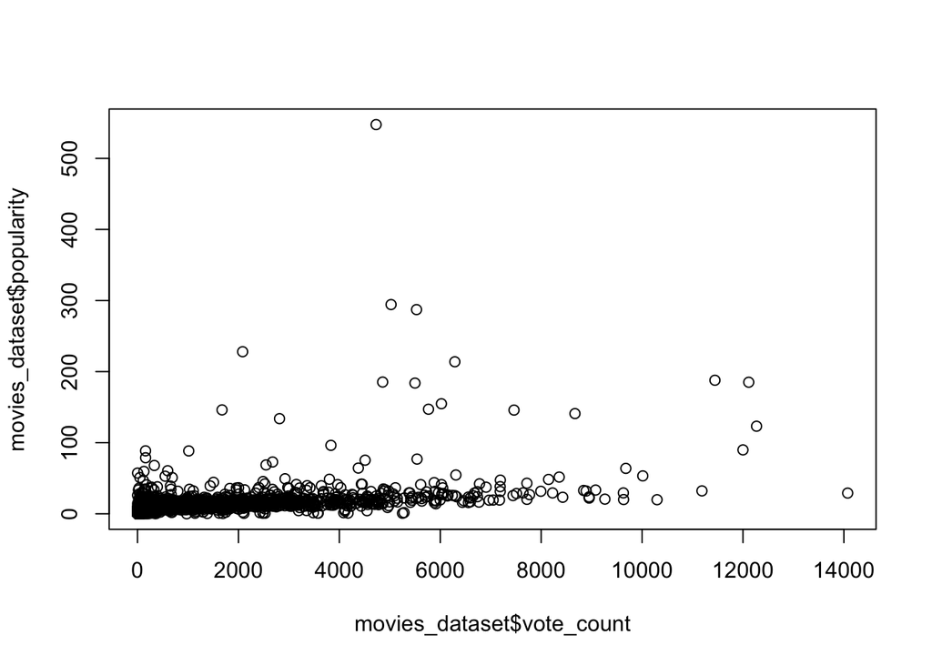

```r
plot(movies_dataset$vote_count, movies_dataset$popularity)
```

A film that with lower than 3.0 vote count and 0.3975 popularity will be described as an unsuccessful movies, which is in the lower 25% quartile. Meanwhile, a film that with higher than 35.0 vote count and 3.7270 popularity will be described as a successful movies, which is in the upper 25% quartile.

### 2.5.8 Average revenue of movies? average revenue by genre? country? etc

```r
average_revenue <- sum(movies_dataset$revenue)/length(movies_dataset)
print(average_revenue)
```

```
## [1] 17907090489
```

For the average revenue of movies by genre:

```r
avg_rev_genre <- tapply(movies_dataset$revenue, movies_dataset$genre1, mean)
sorted_avg_rev_genre <- sort(avg_rev_genre, decreasing = TRUE)
print(sorted_avg_rev_genre)
```

```
##         Adventure         Animation           Fantasy            Action
##       55558673.02       31685090.47       27846623.29       26103745.26
##   Science Fiction            Family          Thriller            Comedy
##       26103228.67       24886536.71        9245708.79        8670279.14
##           Romance             Crime           Mystery           History
##        8128741.22        8093238.32        7584128.17        7127891.10
##            Horror             Drama               War             Music
##        6527363.54        6013012.28        5633162.34        3715969.70
##           Western       Documentary           Foreign          TV Movie
##        3316119.08         306921.75         218813.06         109091.91
##     Not specified
##          80623.98
```

For the average revenue of movies by country:

```r
avg_rev_country <- tapply(movies_dataset$revenue, movies_dataset$PC1, mean)
sorted_avg_rev_country <- sort(avg_rev_country, decreasing = TRUE)
print(head(sorted_avg_rev_country))
```

```
##                New Zealand                    Bahamas
##                   77016824                   37298915
##                      Malta       United Arab Emirates
##                   34705686                   29086598
##                      China   United States of America
##                   26264621                   19152293
```

### 2.5.9 Year in which movie revenue were at its highest

```r
# form a yearly revenue table
movies_dataset$release_year <- substr(movies_dataset$release_date,1,4)
avg_rev_year <- tapply(movies_dataset$revenue, movies_dataset$release_year, sum)
# sort the table in descending order
sorted_avg_rev_year <- sort(avg_rev_year, decreasing = TRUE)
print(sorted_avg_rev_year)
```

```
##        2016        2014        2013        2015        2012        2011
## 30236160953 26349510054 26178040921 26169227708 25324593009 23767582742
##        2010        2009        2008        2007        2006        2004
## 23354715283 21582082082 20650669063 19703464166 18302966486 17666134667
##        2005        2003        2002        2017        2001        1999
## 16812937457 15648237785 15523790519 14554180916 14133875999 12134211309
##        2000        1997        1998        1995        1996        1994
## 11615229925 10629766483  9941993968  8535608383  8447831626  7354819020
##        1993        1992        1990        1989        1991        1988
##  7233120378  6459473655  5788646099  5383889359  5144054753  4272627031
##        1987        1986        1985        1984        1982        1983
##  3474128960  3143979405  3103856504  3035944504  2995813255  2530640602
##        1977        1980        1981        1979        1978        1973
##  2233920578  2139001235  2129659571  2061068854  1606790589  1282801713
##        1975        1976        1974        1967        1970        1965
```

[output cut: 31 more lines]

From the above result, the year that with the highest revenue is 2016, with total movies revenue of $30236160953.

### 2.5.10 Most successful genre of all time and for each region

Firstly, we form a dataframe with mean of popularity in different genres.

```r
avg_pop_genre <- tapply(movies_dataset$popularity, movies_dataset$genre1, mean)
sorted_avg_pop_genre <- sort(avg_pop_genre, decreasing = TRUE)
print(sorted_avg_pop_genre)
```

```
##         Adventure            Action            Family           Fantasy
##         5.5022979         4.6984226         4.5613471         4.4407283
##   Science Fiction         Animation          Thriller            Horror
##         4.2801787         3.9033244         3.6735704         3.4504302
##             Crime           Mystery            Comedy             Drama
##         3.3806918         3.3259225         2.8856970         2.6936254
##           History           Romance               War           Western
##         2.4481151         2.3177770         2.2919012         2.1375803
##          TV Movie             Music       Documentary           Foreign
##         2.1314565         1.7855608         0.9035338         0.6043878
##     Not specified
##         0.3160380
```

The most successful genre is “Adventure”, with an average of 5.5022979 popularity.

### 2.5.11 Production company that has released the majority of recent movies

Let’s define recent years starting from 2010, and then we count the total number of production companies based on the year.

```r
# filter out the films that were released before 2010 & remove the production company that with "Not specified" entry
recent_movies_companies <- movies_dataset %>%
  filter(as.numeric(substring(movies_dataset$release_date,1,4)) > 2009) %>%
  filter(productioncompany1!="  Not specified")
# count the number of production in each company
recent_movies_companies <- aggregate(release_date~productioncompany1, data=recent_movies_companies, FUN=length)
# sort the production company with the film count
sorted_movies_companies <- recent_movies_companies[order(-recent_movies_companies$release_date),]
print(head(sorted_movies_companies))
```

```
##          productioncompany1 release_date
## 4213     Universal Pictures          110
## 937       Columbia Pictures           74
## 3046     Paramount Pictures           74
## 4335   Walt Disney Pictures           63
## 468               BBC Films           56
## 1579        France 2 Cinéma           51
```

Since 2010, the production companies that released the majority of recent movies is “Universal Pictures”, which released 110 films in total.

### 2.5.12 Genre with the most movies

```r
movies_dataset %>%
  dplyr::count(genre1, sort= TRUE)
```

```
##               genre1     n
## 1              Drama 11922
## 2             Comedy  8748
## 3             Action  4479
## 4        Documentary  3395
## 5             Horror  2618
## 6      Not specified  2314
## 7              Crime  1678
## 8           Thriller  1660
## 9          Adventure  1509
## 10           Romance  1182
## 11         Animation  1120
## 12           Fantasy   700
## 13   Science Fiction   641
## 14           Mystery   551
## 15            Family   518
## 16             Music   487
## 17           Western   451
## 18          TV Movie   385
## 19               War   377
## 20           History   277
## 21           Foreign   118
```

Based on the above table, we can conclude that “Drama” is the genre with the most movies, which has 11922 movies in total.

### 2.5.13 Correlation across budget, revenue, votes, ratings, runtime, etc.

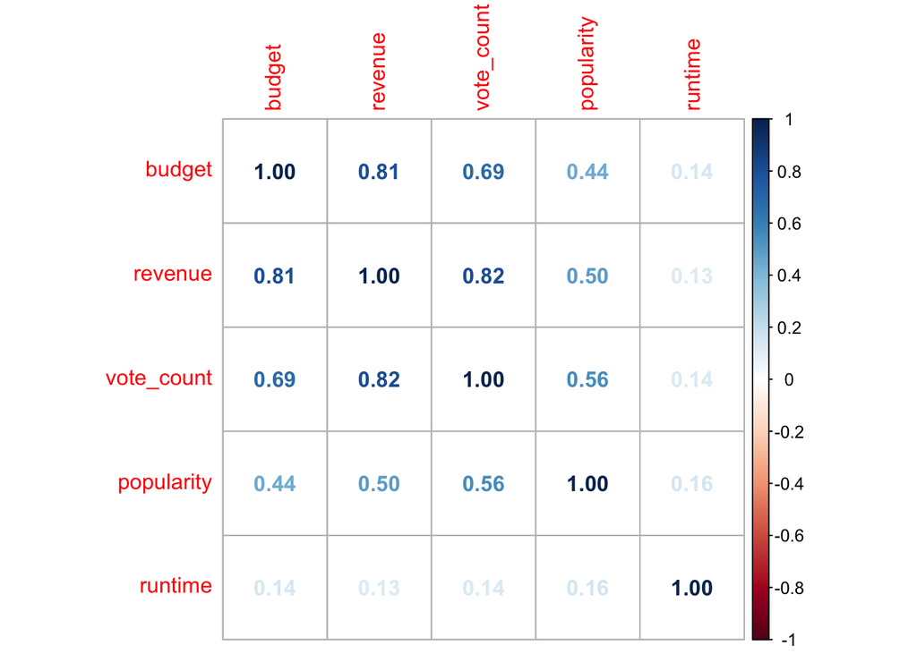

```r
# visualize correlation matrix as number
library(corrplot)
corrplot(cor(movies_dataset[,c("budget", "revenue", "vote_count", "popularity", "runtime")]), method="number")
```

From the correlation matrix, we can observe that variables “vote_count” and “revenue” are also highly positive related (0.82). A positive correlation between vote count and revenue means that as the vote count increases, the revenue tends to increase as well, and as the vote count decreases, the revenue tends to decrease as well.

Moreover, variables “budget” and “revenue” are highly positive related (0.81). One possible explanation for this relationship is that a higher budget allows for higher production values, better marketing, and more resources to attract a larger audience, which can translate into higher revenue. For example, a big-budget movie with high production values and a large marketing campaign may attract more viewers and generate more revenue than a low-budget movie with limited resources and marketing.

And obviously, “runtime” is the less correlated variable among all variables.

## 2.6 New Library

Here I will introduce a function form a new library: “plyr” The full name of function ddply() is called “Data.frame (or array) plyr”. It is used for splitting a data frame into subsets, applying a function to each subset, and then combining the results into a new data frame.

The general syntax for ddply is: **ddply(data, .variables, .fun, …)**

```r
library(plyr)
```

```r
result <- ddply(movies_dataset, .(genre1, language1), summarise, mean_popularity = mean(popularity))
# remove result with "Not specified" items
result <- result %>%
  filter(genre1!="Not specified") %>%
  filter(language1!="Not specified")
```

Here with the code, we can calculate the mean of popularity with different genres and languages.

```r
# view the result
head(result)
```

```
##     genre1          language1 mean_popularity
## 1   Action          Afrikaans       4.9990270
## 2   Action   Bahasa indonesia       5.7380555
## 3   Action      Bahasa melayu       0.2410555
## 4   Action             Català       2.4152860
## 5   Action              Český       5.1363290
## 6   Action              Dansk       3.3737579
```

```r
tail(result)
```

```
##        genre1     language1 mean_popularity
## 689   Western       Deutsch       3.5007948
## 690   Western       English       2.4612320
## 691   Western       Español       3.5770137
## 692   Western      Italiano       1.3832707
## 693   Western   No Language       0.5398547
## 694   Western       Pусский       0.0888120
```

```r
# view the row with the highest mean popularity
max_popularity <- subset(result, mean_popularity == max(result$mean_popularity))
print(max_popularity)
```

```
##         genre1 language1 mean_popularity
## 71   Adventure    Română        76.54256
```

In short, adventure movies in Romanian is the best combination in term of popularity.

## 2.8 Conclusions and Business Recommendations

**Conclusions:**

**Business Recommendations:**

Studios should consider producing more movies in languages other than English to attract a wider audience.

# 3 End Matter

## 3.1 Appendices

Please refer to the Rmd file “Evidence 1.Rmd”.

## 3.2 Reference List

R Core Team (2021). “R: A language and environment for statistical computing”. R Foundation for Statistical Computing, Vienna, Austria. Retrieved from https://www.R-project.org/.

ROUNAK BANIK. “The Movies Dataset”. Kaggle. Retrieved from https://www.kaggle.com/datasets/rounakbanik/the-movies-dataset?select=movies_metadata.csv.